# Final Project - Data Science 1

```python
from IPython.display import HTML

HTML('''
<script src='//code.jquery.com/jquery-3.3.1.min.js'></script>
<script>
code_show=true;
function code_toggle() {
if (code_show){
$('div.input').hide();
$('div .jp-CodeCell .jp-Cell-inputWrapper').hide();
} else {
$('div.input').show();
$('div .jp-CodeCell .jp-Cell-inputWrapper').show();
}
code_show = !code_show
}
$( document ).ready(code_toggle);
</script>
<form action="javascript:code_toggle()"><input type="submit" value="Code on/off"></form>''')
```

```python
import pandas as pd
import numpy as np
import seaborn as sns

import matplotlib.pyplot as plt
from matplotlib import style
style.use("ggplot")
from sklearn.cluster import KMeans
from sklearn.decomposition import PCA
from sklearn import preprocessing
from sklearn.preprocessing import StandardScaler

%matplotlib inline
```

### Abstract

The main features which make the movie a blockbuster are hard to say. It is easy to guess what it might be but that might not be the real reason. Here the goal was to do Extrapolatory data analysis and come out with a conclusion using **Python**. This report was done using 2 Datasets from IMDB and TMDB. One had 28 features and the other 20 Each had around close to 5000 movies. The top Directors do have a crucial role in making the movie successful. Some features in the movie database are extremely correlated and some have no significance. Facenbook likes among actors and cast are more related and financial outcome like budget, gross income, popularity, critics are more related.

### Introduction and Background

Movies have a huge impact on society. Nowadays people don’t just watch movies but they adapt a lot of information from the cinematic world. It has the capacity to influence community both locally and globally. Many kinds of movies are made each year. Each is review and criticised by many organisation.  
A lot of effort goes into making a movie. It can turn out to be a success or failure depending on various factors. Factors like the choice of Director, Actor, theme, budget, storyline, etc. The theme, direction, storyline of movies all are also changing with time. The trend and direction of the movie industry are evolving over time. The aim of this report is to analyse the trend and how the features in the movie database are correlated.

Here two datasets from two movies database has been used to analyse the trend:

```python
tmdb_movies = pd.read_csv("Dataset_all/tmdb_5000_movies.csv")
movie_metadata = pd.read_csv("Dataset_all/movie_metadata.csv")

print('1. The movie_metadata (IMDB) dataset contains:', len(movie_metadata),' movies and',len(movie_metadata.columns),'features.')
print('2. The tmdb_movies (TMBD) dataset contains:', len(tmdb_movies),' movies and',len(tmdb_movies.columns),'features.')
```

```
1. The movie_metadata (IMDB) dataset contains: 5043  movies and 28 features.
2. The tmdb_movies (TMBD) dataset contains: 4803  movies and 20 features.
```

```python
print('Below are the 28 features of IMDB dataset: \n ')
s_m=sorted( movie_metadata.columns)
for col1 in s_m:
    print(col1, end=' . ')

print('\n \nBelow are the 20 features of TMBD dataset: \n')

s_t=sorted( tmdb_movies.columns)
for col2 in s_t:
    print( col2,  end=' . ')
```

```
Below are the 28 features of IMDB dataset:

actor_1_facebook_likes . actor_1_name . actor_2_facebook_likes . actor_2_name . actor_3_facebook_likes . actor_3_name . aspect_ratio . budget . cast_total_facebook_likes . color . content_rating . country . director_facebook_likes . director_name . duration . facenumber_in_poster . genres . gross . …

Below are the 20 features of TMBD dataset:

budget . genres . homepage . id . keywords . original_language . original_title . overview . popularity . production_companies . production_countries . release_date . revenue . runtime . spoken_languages . status . tagline . title . vote_average . vote_count .
```

IMDB Dataset time span is across 100 years in 66 countries, as well as gross earnings. There are 2399 unique director names and thousands of actors/actresses. TMDB also spans across 101 years (1916-2017.

#### The aim is to find a trend in the movie industry. By answering the following:

#### 1. Does having a popular Director increase the chance of having a movie? Merge the dataset and find the relation. Name the popular Director making the highest revenue in movies.

#### 2. Through a Correlation Analysis find a relation between the features in the movie set. Which are the most related features?

#### 3. Perform PCA to find a trend ain the movie features.

### Methodology

For running the analysis in python few libraries had to be loaded. For Principal Component Analysis – the sklearn library was imported. Standardise the data with sklearn's StandardScaler. Run the PCA with sklearn.decomposition .  
For plots to showcase - seaborn, matplotlib, ggplot are imported from the library.

As every other dataset after loading the dataset, it had to be cleaned. All NaNs (empty values) were removed. To find the popular director two datasets were merged. They were merged by the movie title names but had an issue. As they were from different database there writing style was different as well. After troubleshoot it was found that in the IMDB - movie names column they had right white space, which was necessary to remove. After removing all the right white space from the column the two datasets were merged by inner joint and formed the new combined dataset of 4516 movies and 48 features.

The Data Frame of the combined data is right below.

```python
#filtering NaN and removing it

movie_metadata =movie_metadata.dropna()
tmdb_movies = tmdb_movies.dropna()

# removing a right space frm movie-title column otherwise they won't merge properly
movie_metadata['movie_title']=movie_metadata['movie_title'].str.rstrip()

combine_df =pd.merge(movie_metadata,tmdb_movies,  left_on="movie_title",right_on="original_title", how='inner') #merging the tables by movie title and only movies which were common in both dataset is used.
combine_df.head()
#combine_df.shape=(4516, 48)
```

|  | color | director_name | num_critic_for_reviews | duration | director_facebook_likes | actor_3_facebook_likes | actor_2_name | actor_1_facebook_likes | gross | genres_x | ... | production_countries | release_date | revenue | runtime | spoken_languages | status | tagline | title | vote_average | vote_count |
| --- | --- | --- | --- | --- | --- | --- | --- | --- | --- | --- | --- | --- | --- | --- | --- | --- | --- | --- | --- | --- | --- |
| 0 | Color | James Cameron | 723.0 | 178.0 | 0.0 | 855.0 | Joel David Moore | 1000.0 | 760505847.0 | Action\|Adventure\|Fantasy\|Sci-Fi | ... | [{"iso_3166_1": "US", "name": "United States o... | 2009-12-10 | 2787965087 | 162.0 | [{"iso_639_1": "en", "name": "English"}, {"iso... | Released | Enter the World of Pandora. | Avatar | 7.2 | 11800 |
| 1 | Color | Gore Verbinski | 302.0 | 169.0 | 563.0 | 1000.0 | Orlando Bloom | 40000.0 | 309404152.0 | Action\|Adventure\|Fantasy | ... | [{"iso_3166_1": "US", "name": "United States o... | 2007-05-19 | 961000000 | 169.0 | [{"iso_639_1": "en", "name": "English"}] | Released | At the end of the world, the adventure begins. | Pirates of the Caribbean: At World's End | 6.9 | 4500 |
| 2 | Color | Sam Mendes | 602.0 | 148.0 | 0.0 | 161.0 | Rory Kinnear | 11000.0 | 200074175.0 | Action\|Adventure\|Thriller | ... | [{"iso_3166_1": "GB", "name": "United Kingdom"... | 2015-10-26 | 880674609 | 148.0 | [{"iso_639_1": "fr", "name": "Fran\u00e7ais"},... | Released | A Plan No One Escapes | Spectre | 6.3 | 4466 |
| 3 | Color | Christopher Nolan | 813.0 | 164.0 | 22000.0 | 23000.0 | Christian Bale | 27000.0 | 448130642.0 | Action\|Thriller | ... | [{"iso_3166_1": "US", "name": "United States o... | 2012-07-16 | 1084939099 | 165.0 | [{"iso_639_1": "en", "name": "English"}] | Released | The Legend Ends | The Dark Knight Rises | 7.6 | 9106 |
| 4 | Color | Andrew Stanton | 462.0 | 132.0 | 475.0 | 530.0 | Samantha Morton | 640.0 | 73058679.0 | Action\|Adventure\|Sci-Fi | ... | [{"iso_3166_1": "US", "name": "United States o... | 2012-03-07 | 284139100 | 132.0 | [{"iso_639_1": "en", "name": "English"}] | Released | Lost in our world, found in another. | John Carter | 6.1 | 2124 |

5 rows × 48 columns

From this combined data frame names of the popular director with there mean IMDB score, TMDB score, popularity and movie revenue made is found in the table. Few Exploratory Data Analyse will be found in the Appendix.

Cluster map and correlation heat map is used to interpret the data.For correlation the data had to be cleaned again by producing a data frame only with selected columns and with numerical values only. Afterwards formed the correlation heatmap with the correlation coefficient. The clustermap maps the matrix/data frame in hierarchically-clustered map. This allows seeing the bigger picture in hierarchical order. It shows how many clusters can be made.

For PCA firstly used 3 features from the merged data set. Then used the stand algorithm for normalizing the data and fitting the PCA model. Got the output of the PCA variance ratio. Secondly plotted the no. of components against cumulative explained variance. Thirdly formed the table of PCA score and the scatterplot of it. At the last plotted the biplot. The combined graph of loadings and PCA scores.

### Results

#### Popular Directors

From the table generated below, it interprets that-  
The top 10 Director who has given the biggest films are:-  
James Cameron, Joss Whedon, Colin Trevorrow, James Wan, Joss Whedon, Chris Buck, Shane Black, Kyle Balda, Antony Russo, and Machael Bay.  
Their movies have generated the highest revenue at there time. The table shows the IMDB and TMDB score, the popularity of the movie entirely and the revenue generated from it. This says a lot of information, that the success of the movie does depends on how the director is directing the movie and how he pulls it off till the end. These names are quite popular in the movie industry. And few of the names has repeted as well.

```python
# calling the desied columns and doing group
c2=combine_df.groupby(['director_name','vote_average','imdb_score' ,'popularity','movie_title'])['revenue'].mean().sort_values(ascending=False).head(20)
c2.to_frame() # making it into dataframe
```

| director_name | vote_average | imdb_score | popularity | movie_title | revenue |
| --- | --- | --- | --- | --- | --- |
| James Cameron | 7.2 | 7.9 | 150.437577 | Avatar | 2787965087 |
|  | 7.5 | 7.7 | 100.025899 | Titanic | 1845034188 |
| Joss Whedon | 7.4 | 8.1 | 144.448633 | The Avengers | 1519557910 |
| Colin Trevorrow | 6.5 | 7.0 | 418.708552 | Jurassic World | 1513528810 |
| James Wan | 7.3 | 7.2 | 102.322217 | Furious 7 | 1506249360 |
| Joss Whedon | 7.3 | 7.5 | 134.279229 | Avengers: Age of Ultron | 1405403694 |
| Chris Buck | 7.3 | 7.6 | 165.125366 | Frozen | 1274219009 |
| Shane Black | 6.8 | 7.2 | 77.682080 | Iron Man 3 | 1215439994 |
| Kyle Balda | 6.4 | 6.4 | 875.581305 | Minions | 1156730962 |
| Anthony Russo | 7.1 | 8.2 | 198.372395 | Captain America: Civil War | 1153304495 |
| Michael Bay | 6.1 | 6.3 | 28.529607 | Transformers: Dark of the Moon | 1123746996 |
| Peter Jackson | 8.1 | 8.9 | 123.630332 | The Lord of the Rings: The Return of the King | 1118888979 |
| Sam Mendes | 6.9 | 7.8 | 93.004993 | Skyfall | 1108561013 |
| Michael Bay | 5.8 | 5.7 | 116.840296 | Transformers: Age of Extinction | 1091405097 |
| Christopher Nolan | 7.6 | 8.5 | 112.312950 | The Dark Knight Rises | 1084939099 |
| Lee Unkrich | 7.6 | 8.3 | 59.995418 | Toy Story 3 | 1066969703 |
| Gore Verbinski | 7.0 | 7.3 | 145.847379 | Pirates of the Caribbean: Dead Man's Chest | 1065659812 |
| Rob Marshall | 6.4 | 6.7 | 135.413856 | Pirates of the Caribbean: On Stranger Tides | 1045713802 |
| Tim Burton | 6.4 | 6.5 | 78.530105 | Alice in Wonderland | 1025491110 |
| Christopher Nolan | 8.2 | 9.0 | 187.322927 | The Dark Knight | 1004558444 |

#### Correlation Analysis

The correlation heatmap and cluster map show the relationship between each feature. The lighter the color the stronger the correlation.

The clustermap maps the matrix in a hierarchically-clustered map. It shows there are 3 major clusters.

- IMBD score, TMDB score(vote_average) can be clustered as one. But since it does not have much relation but other features it is clustered with Director Facebook likes.
- Actor/Actress (first, second, third) along with other member in the cast; their facebook likes are more correlated.
- And the rest of the features which includes financial count, critic reviews, user reviews, popularity and movie facebook likes are correlated and they can be clustered together.

```python
#preparing data frame for correlation
# filtering num values only
str_list=[] #empty list
for colname, colvalue in combine_df.iteritems():
    if type(colvalue[1])==str:
        str_list.append(colname)
num_list= combine_df.columns.difference(str_list) # will get only numeric values
combine_df_new = combine_df[num_list]
#combine_df_new.head()    #shape=4516 rows × 23 columns
```

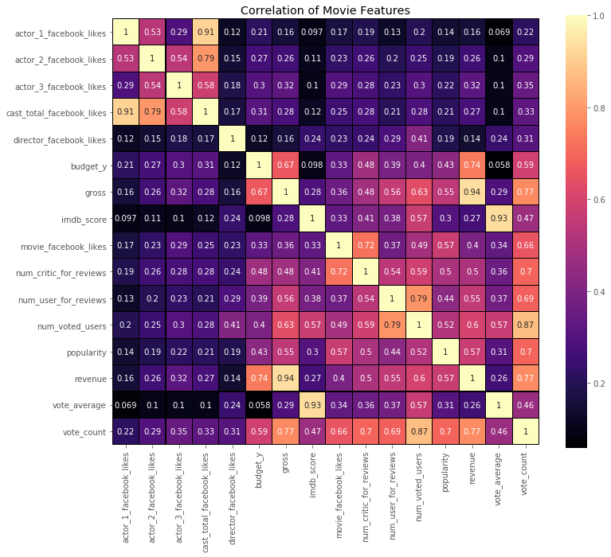

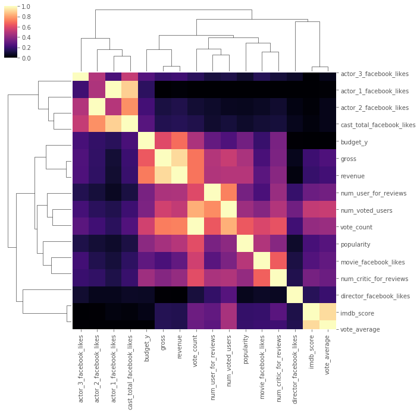

```python
col4=['actor_1_facebook_likes','actor_2_facebook_likes','actor_3_facebook_likes','cast_total_facebook_likes','director_facebook_likes','budget_y','gross','imdb_score','movie_facebook_likes','num_critic_for_reviews','num_user_for_reviews','num_voted_users','popularity','revenue','vote_average','vote_count']
corr_df=combine_df_new[col4]
f,ax=plt.subplots(figsize=(12,10))
plt.title('Correlation of Movie Features')
sns.heatmap(corr_df.astype(float).corr(), linewidths=0.25, vmax=1.0,square=True, cmap="magma", linecolor="black", annot=True )
bottom, top = ax.get_ylim()
ax.set_ylim(bottom + 0.5, top - 0.5)
plt.show()
sns.clustermap(corr_df.corr(),cmap="magma",standard_scale=1)
plt.show()
```

#### Principal Component Analysis

Used Principal Component Analysis for unsupervised learning. To find the pattern in the data. Here we chose 3 features- polarity, revenue, imdb_score. And found three pca explained variance ratio.

```python
a1=[ 'popularity','revenue','imdb_score' ]
x=combine_df[a1]  #formed the data for pca
x.head()
```

|  | popularity | revenue | imdb_score |
| --- | --- | --- | --- |
| 0 | 150.437577 | 2787965087 | 7.9 |
| 1 | 139.082615 | 961000000 | 7.1 |
| 2 | 107.376788 | 880674609 | 6.8 |
| 3 | 112.312950 | 1084939099 | 8.5 |
| 4 | 43.926995 | 284139100 | 6.6 |

```python
T=x.values #assing all values to T

scaler = StandardScaler() # normalizing the data
T_scaled=scaler.fit_transform(T) #fitting the transforming the values
```

```python
pca = PCA()
T_7d=pca.fit_transform(T_scaled)
print('pca explained variance ratio =',pca.explained_variance_ratio_)
```

```
pca explained variance ratio = [0.59308083 0.26451655 0.14240262]
```

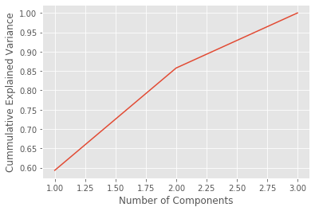

```python
components = np.arange(1,4)
plt.plot(components, np.cumsum(pca.explained_variance_ratio_))

plt.xlabel('Number of Components')
plt.ylabel('Cummulative Explained Variance')
plt.show()
```

```python
pca = PCA(n_components=2)
pca.fit(T_scaled)
pca_loadings = pca.components_  #loaded the loading value
pca_scores = pca.fit_transform(T_scaled)  #formed the pca scores
#Note that we have collapsed the dimmensionality of our space from 3 dimensions to 2 dimensions
```

The plot looks like its clustered around the corner but it fans out later in the opposite direction.

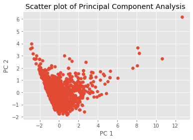

```python
plt.scatter(pca_scores[:,0], pca_scores[:,1] )
plt.xlabel('PC 1')
plt.ylabel('PC 2')
plt.title('Scatter plot of Principal Component Analysis ')
```

It looks like revenue and popularity is more correlated. The ﬁrst PC is a combination of revenue, popularity and IMDB score. The second PC is a little bit more dominated by IMDB score.

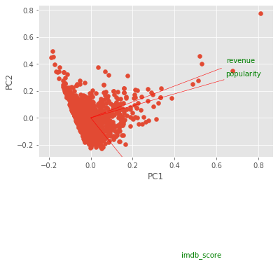

```python
def myplot(score,coeff,labels=None):
    xs = score[:,0]
    ys = score[:,1]
    n = coeff.shape[0]
    scalex = 1.0/(xs.max() - xs.min())
    scaley = 1.0/(ys.max() - ys.min())
    plt.scatter(xs * scalex,ys * scaley)
    for i in range(n):
        plt.arrow(0, 0, coeff[i,0], coeff[i,1],color = 'r',alpha = 0.5)
        if labels is None:
            plt.text(coeff[i,0]* 1.15, coeff[i,1] * 1.15, a1[i], color = 'g', ha = 'center', va = 'center')
        else:
            plt.text(coeff[i,0]* 1.15, coeff[i,1] * 1.15, labels[i], color = 'g', ha = 'center', va = 'center')
            plt.xlim(-1,1)
            plt.ylim(-1,1)
            plt.xlabel("PC1")
            plt.ylabel("PC2")
            plt.grid()

myplot(pca_scores[:,0:2],np.transpose(pca.components_[0:2, :]))
plt.xlabel("PC1")
plt.ylabel("PC2")
```

### Appendix

The dataset from TMDB.

```python
#Appendix 1
tmdb_movies = pd.read_csv("Dataset_all/tmdb_5000_movies.csv")
tmdb_movies.head(2)
#tmdb_movies.shape=(4803, 20)
```

|  | budget | genres | homepage | id | keywords | original_language | original_title | overview | popularity | production_companies | production_countries | release_date | revenue | runtime | spoken_languages | status | tagline | title | vote_average | vote_count |
| --- | --- | --- | --- | --- | --- | --- | --- | --- | --- | --- | --- | --- | --- | --- | --- | --- | --- | --- | --- | --- |
| 0 | 237000000 | [{"id": 28, "name": "Action"}, {"id": 12, "nam... | http://www.avatarmovie.com/ | 19995 | [{"id": 1463, "name": "culture clash"}, {"id":... | en | Avatar | In the 22nd century, a paraplegic Marine is di... | 150.437577 | [{"name": "Ingenious Film Partners", "id": 289... | [{"iso_3166_1": "US", "name": "United States o... | 2009-12-10 | 2787965087 | 162.0 | [{"iso_639_1": "en", "name": "English"}, {"iso... | Released | Enter the World of Pandora. | Avatar | 7.2 | 11800 |
| 1 | 300000000 | [{"id": 12, "name": "Adventure"}, {"id": 14, "... | http://disney.go.com/disneypictures/pirates/ | 285 | [{"id": 270, "name": "ocean"}, {"id": 726, "na... | en | Pirates of the Caribbean: At World's End | Captain Barbossa, long believed to be dead, ha... | 139.082615 | [{"name": "Walt Disney Pictures", "id": 2}, {"... | [{"iso_3166_1": "US", "name": "United States o... | 2007-05-19 | 961000000 | 169.0 | [{"iso_639_1": "en", "name": "English"}] | Released | At the end of the world, the adventure begins. | Pirates of the Caribbean: At World's End | 6.9 | 4500 |

The dataset from IMDB.

```python
#Appendix 2

movie_metadata = pd.read_csv("Dataset_all/movie_metadata.csv")
movie_metadata.head(3)
#movie_metadata.shape=(5043, 28)
```

|  | color | director_name | num_critic_for_reviews | duration | director_facebook_likes | actor_3_facebook_likes | actor_2_name | actor_1_facebook_likes | gross | genres | ... | num_user_for_reviews | language | country | content_rating | budget | title_year | actor_2_facebook_likes | imdb_score | aspect_ratio | movie_facebook_likes |
| --- | --- | --- | --- | --- | --- | --- | --- | --- | --- | --- | --- | --- | --- | --- | --- | --- | --- | --- | --- | --- | --- |
| 0 | Color | James Cameron | 723.0 | 178.0 | 0.0 | 855.0 | Joel David Moore | 1000.0 | 760505847.0 | Action\|Adventure\|Fantasy\|Sci-Fi | ... | 3054.0 | English | USA | PG-13 | 237000000.0 | 2009.0 | 936.0 | 7.9 | 1.78 | 33000 |
| 1 | Color | Gore Verbinski | 302.0 | 169.0 | 563.0 | 1000.0 | Orlando Bloom | 40000.0 | 309404152.0 | Action\|Adventure\|Fantasy | ... | 1238.0 | English | USA | PG-13 | 300000000.0 | 2007.0 | 5000.0 | 7.1 | 2.35 | 0 |
| 2 | Color | Sam Mendes | 602.0 | 148.0 | 0.0 | 161.0 | Rory Kinnear | 11000.0 | 200074175.0 | Action\|Adventure\|Thriller | ... | 994.0 | English | UK | PG-13 | 245000000.0 | 2015.0 | 393.0 | 6.8 | 2.35 | 85000 |

3 rows × 28 columns

```python
#Appendix 3

c3=['director_name','imdb_score','movie_title']
c4=combine_df[c3]
c4 = c4[(c4[['director_name']] != 0).all(axis=1)]

director_1=c4.groupby(["director_name","movie_title"])["imdb_score"].max().sort_values(ascending=False).head(15) # finding the median value of each neighbourhood_group)
director_1
```

```
director_name         movie_title
Francis Ford Coppola  The Godfather                                        9.2
Christopher Nolan     The Dark Knight                                      9.0
Peter Jackson         The Lord of the Rings: The Return of the King        8.9
Steven Spielberg      Schindler's List                                     8.9
Christopher Nolan     Inception                                            8.8
David Fincher         Fight Club                                           8.8
Peter Jackson         The Lord of the Rings: The Fellowship of the Ring    8.8
                      The Lord of the Rings: The Two Towers                8.7
Lana Wachowski        The Matrix                                           8.7
Christopher Nolan     Interstellar                                         8.6
Tony Kaye             American History X                                   8.6
Bryan Singer          The Usual Suspects                                   8.6
David Fincher         Se7en                                                8.6
Robert Zemeckis       Back to the Future                                   8.5
Frank Darabont        The Green Mile                                       8.5
Name: imdb_score, dtype: float64
```

```python
# calling the desied columns and doing group
c2=combine_df.groupby(['director_name','vote_average','imdb_score' ,'popularity','movie_title'])['budget_x'].mean().sort_values(ascending=False).head(20)
c2.to_frame() # making it into dataframe
```

| director_name | vote_average | imdb_score | popularity | movie_title | budget_x |
| --- | --- | --- | --- | --- | --- |
| Gore Verbinski | 6.9 | 7.1 | 139.082615 | Pirates of the Caribbean: At World's End | 300000000.0 |
| Andrew Stanton | 6.1 | 6.6 | 43.926995 | John Carter | 263700000.0 |
| Nathan Greno | 7.4 | 7.8 | 48.681969 | Tangled | 260000000.0 |
| Sam Raimi | 5.9 | 6.2 | 115.699814 | Spider-Man 3 | 258000000.0 |
| Joss Whedon | 7.3 | 7.5 | 134.279229 | Avengers: Age of Ultron | 250000000.0 |
| David Yates | 7.4 | 7.5 | 98.885637 | Harry Potter and the Half-Blood Prince | 250000000.0 |
| Peter Jackson | 7.1 | 7.5 | 120.965743 | The Hobbit: The Battle of the Five Armies | 250000000.0 |
| Rob Marshall | 6.4 | 6.7 | 135.413856 | Pirates of the Caribbean: On Stranger Tides | 250000000.0 |
| Zack Snyder | 5.7 | 6.9 | 155.790452 | Batman v Superman: Dawn of Justice | 250000000.0 |
| Christopher Nolan | 7.6 | 8.5 | 112.312950 | The Dark Knight Rises | 250000000.0 |
| Anthony Russo | 7.1 | 8.2 | 198.372395 | Captain America: Civil War | 250000000.0 |
| Sam Mendes | 6.3 | 6.8 | 107.376788 | Spectre | 245000000.0 |
| James Cameron | 7.2 | 7.9 | 150.437577 | Avatar | 237000000.0 |
| Marc Webb | 6.5 | 7.0 | 89.866276 | The Amazing Spider-Man | 230000000.0 |
| Peter Jackson | 7.6 | 7.9 | 94.370564 | The Hobbit: The Desolation of Smaug | 225000000.0 |
| Barry Sonnenfeld | 6.2 | 6.8 | 52.035179 | Men in Black 3 | 225000000.0 |
| Gore Verbinski | 7.0 | 7.3 | 145.847379 | Pirates of the Caribbean: Dead Man's Chest | 225000000.0 |
| Zack Snyder | 6.5 | 7.2 | 99.398009 | Man of Steel | 225000000.0 |
| Joss Whedon | 7.4 | 8.1 | 144.448633 | The Avengers | 220000000.0 |
| Gore Verbinski | 5.9 | 6.5 | 49.046956 | The Lone Ranger | 215000000.0 |

```python
#Appendix 4

a1=['director_name','imdb_score','movie_title', 'revenue', 'gross']
a2=combine_df[a1]
a2 = a2[(a2[['director_name', 'revenue']] != 0).all(axis=1)]

director_2=a2.groupby(["director_name","movie_title",'revenue','gross'])["imdb_score"].max().sort_values(ascending=False).head(15) # finding the median value of each neighbourhood_group)
director_2
```

```
director_name         movie_title                                        revenue     gross
Francis Ford Coppola  The Godfather                                      245066411   134821952.0    9.2
Christopher Nolan     The Dark Knight                                    1004558444  533316061.0    9.0
Steven Spielberg      Schindler's List                                   321365567   96067179.0     8.9
Peter Jackson         The Lord of the Rings: The Return of the King      1118888979  377019252.0    8.9
Christopher Nolan     Inception                                          825532764   292568851.0    8.8
David Fincher         Fight Club                                         100853753   37023395.0     8.8
Peter Jackson         The Lord of the Rings: The Fellowship of the Ring  871368364   313837577.0    8.8
Lana Wachowski        The Matrix                                         463517383   171383253.0    8.7
Peter Jackson         The Lord of the Rings: The Two Towers              926287400   340478898.0    8.7
Tony Kaye             American History X                                 23875127    6712241.0      8.6
David Fincher         Se7en                                              327311859   100125340.0    8.6
Bryan Singer          The Usual Suspects                                 23341568    23272306.0     8.6
Christopher Nolan     Interstellar                                       675120017   187991439.0    8.6
                      The Dark Knight Rises                              1084939099  448130642.0    8.5
Ridley Scott          Alien                                              104931801   78900000.0     8.5
Name: imdb_score, dtype: float64
```

[figure not shown]

```
director_name    imdb_score
James Cameron    7.9           2.787965e+09
                 7.7           1.845034e+09
Joss Whedon      8.1           1.519558e+09
Colin Trevorrow  7.0           1.513529e+09
James Wan        7.2           1.506249e+09
Joss Whedon      7.5           1.405404e+09
Chris Buck       7.6           1.274219e+09
Shane Black      7.2           1.215440e+09
Kyle Balda       6.4           1.156731e+09
Anthony Russo    8.2           1.153304e+09
Michael Bay      6.3           1.123747e+09
Peter Jackson    8.9           1.118889e+09
Sam Mendes       7.8           1.108561e+09
Michael Bay      5.7           1.091405e+09
Lee Unkrich      8.3           1.066970e+09
Name: revenue, dtype: float64
```

```python
#Appendix 5
c=combine_df.groupby(['director_name','imdb_score' ])['revenue'].mean().sort_values(ascending=False).head(15)


plt.figure(figsize=(11,11))   #fixing a default size of figure
plt.style.use('fivethirtyeight')    #chosing style, colour of plot
c.unstack().plot.barh()

plt.title("Barplot of the Director names and revenue earned by the movie with its IMDB score", fontsize=18) #lablelling title
plt.ylabel("Director names", fontsize=18)      #lablelling y-axis
plt.xlabel("Revenue in billion", fontsize=18)           #lablelling x-axis
plt.legend(fontsize=11,loc=0)       #fixing the postion of legend in asuitable place, with front size-11
plt.xticks(fontsize=15)            #fixing font size of the x axis elements
plt.yticks(fontsize=15)                  #fixing font size of the y axis elements


plt.show()
print(c.head(15))
```

Correlation map of combined data set. It shows similarity between facebook likes in one group. the financial variables and critics reviews, user reviews , popularity ,ets in another group.

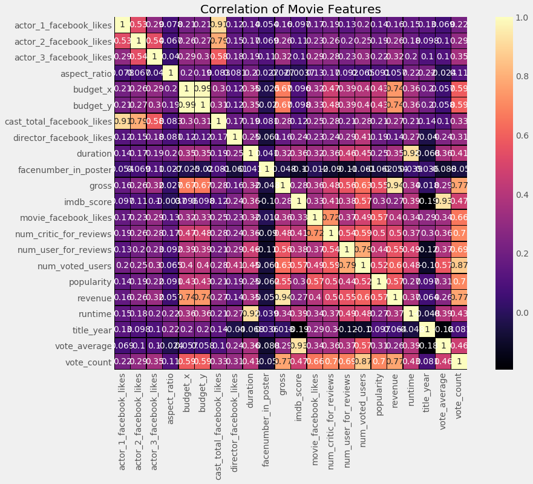

```python
##Appendix 7

no_id_c=combine_df_new.drop(columns=['id'])
f,ax=plt.subplots(figsize=(15,10))
plt.title('Correlation of Movie Features')
sns.heatmap(no_id_c.astype(float).corr(), linewidths=0.25, vmax=1.0, square=True, cmap="magma", linecolor="black", annot=True )
bottom, top = ax.get_ylim()
ax.set_ylim(bottom + 0.5, top - 0.5)
plt.show()
```

Producing a data frame only with numerical value of TMDB

```python
# filtering data output is only numerical values

str_list2=[] #empty list
for colname, colvalue in tmdb_movies.iteritems():
    if type(colvalue[1])==str:
        str_list2.append(colname)
num_list= tmdb_movies.columns.difference(str_list2) # will get only numeric values
tmdb_m_num = tmdb_movies[num_list]
tmdb_m_num #shape=4803 x 7
```

|  | budget | id | popularity | revenue | runtime | vote_average | vote_count |
| --- | --- | --- | --- | --- | --- | --- | --- |
| 0 | 237000000 | 19995 | 150.437577 | 2787965087 | 162.0 | 7.2 | 11800 |
| 1 | 300000000 | 285 | 139.082615 | 961000000 | 169.0 | 6.9 | 4500 |
| 2 | 245000000 | 206647 | 107.376788 | 880674609 | 148.0 | 6.3 | 4466 |
| 3 | 250000000 | 49026 | 112.312950 | 1084939099 | 165.0 | 7.6 | 9106 |
| 4 | 260000000 | 49529 | 43.926995 | 284139100 | 132.0 | 6.1 | 2124 |
| ... | ... | ... | ... | ... | ... | ... | ... |
| 4798 | 220000 | 9367 | 14.269792 | 2040920 | 81.0 | 6.6 | 238 |
| 4799 | 9000 | 72766 | 0.642552 | 0 | 85.0 | 5.9 | 5 |
| 4800 | 0 | 231617 | 1.444476 | 0 | 120.0 | 7.0 | 6 |
| 4801 | 0 | 126186 | 0.857008 | 0 | 98.0 | 5.7 | 7 |
| 4802 | 0 | 25975 | 1.929883 | 0 | 90.0 | 6.3 | 16 |

4803 rows × 7 columns

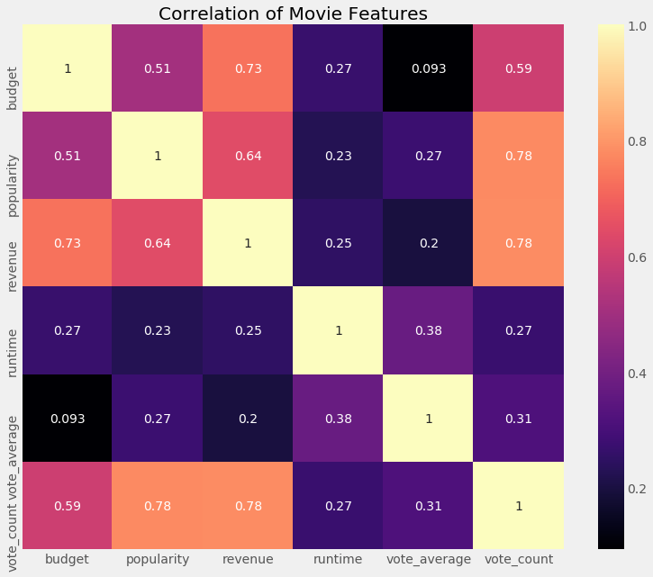

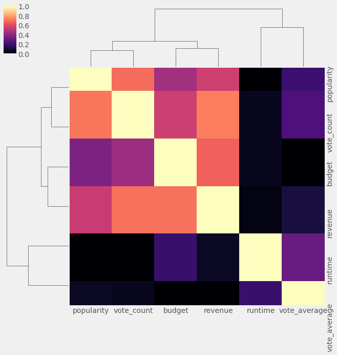

```python
#ap
no_id_tmdb_m_num=tmdb_m_num.drop(columns=['id'])

plt.figure(figsize=(12,10))
plt.title('Correlation of Movie Features')
ax=sns.heatmap(no_id_tmdb_m_num.astype(float).corr(), vmax=1,  cmap="magma", linecolor="black",annot=True)
bottom, top = ax.get_ylim()
ax.set_ylim(bottom + 0.5, top - 0.5)
plt.show()
sns.clustermap(no_id_tmdb_m_num.corr(),cmap="magma",standard_scale=1)
plt.show()
#with sns.axes_style("white"):
#    ax = sns.heatmap(corr, mask=mask, vmax=.3, square=True,  cmap="YlGnBu")
#    plt.show()
```